# Client Report - Flights: Column Aggregation

- Show All Code
- Hide All Code

Unit 2 Task 2

Author

[Davi Freitas]

```python
import polars as pl
import requests #new for reading in JSON
import io       #new for reading in JSON
import numpy as np
from lets_plot import *

LetsPlot.setup_html(isolated_frame=True)
```

```python
# Learn morea about Code Cells: https://quarto.org/docs/reference/cells/cells-jupyter.html

# Include and execute your code here
url = "https://raw.githubusercontent.com/byuidatascience/data4missing/master/data-raw/flights_missing/flights_missing.json"
response = requests.get(url)
df = pl.read_json(io.BytesIO(response.content))
df.head()
```

shape: (5, 17)

| airport_code str | airport_name str | month str | year i64 | num_of_flights_total i64 | num_of_delays_carrier str | num_of_delays_late_aircraft i64 | num_of_delays_nas i64 | num_of_delays_security i64 | num_of_delays_weather i64 | num_of_delays_total i64 | minutes_delayed_carrier i64 | minutes_delayed_late_aircraft i64 | minutes_delayed_nas i64 | minutes_delayed_security i64 | minutes_delayed_weather i64 | minutes_delayed_total i64 |
| --- | --- | --- | --- | --- | --- | --- | --- | --- | --- | --- | --- | --- | --- | --- | --- | --- |
| "ATL" | "Atlanta, GA: Hartsfield-Jackso… | "January" | 2005 | 35048 | "1500+" | -999 | 4598 | 10 | 448 | 8355 | 116423 | 104415 | 207467 | 297 | 36931 | 465533 |
| "DEN" | "Denver, CO: Denver Internation… | "January" | 2005 | 12687 | "1041" | 928 | 935 | 11 | 233 | 3153 | 53537 | 70301 | 36817 | 363 | 21779 | 182797 |
| "IAD" | "" | "January" | 2005 | 12381 | "414" | 1058 | 895 | 4 | 61 | 2430 | null | 70919 | 35660 | 208 | 4497 | 134881 |
| "ORD" | "Chicago, IL: Chicago O'Hare In… | "January" | 2005 | 28194 | "1197" | 2255 | 5415 | 5 | 306 | 9178 | 88691 | 160811 | 364382 | 151 | 24859 | 638894 |
| "SAN" | "San Diego, CA: San Diego Inter… | "January" | 2005 | 7283 | "572" | 680 | 638 | 7 | 56 | 1952 | 27436 | 38445 | 21127 | 218 | 4326 | 91552 |

## QUESTION 1

**Calculate the sample size (i.e. number of rows in the dataset) for each airport in each year**. What do you notice?

I noticed that there are 89 combinations of airport and years, being 8 different airports and 12 different years. In addition, there is one airport the name was not reported and that has less months reported than it should have.

```python
# Include and execute your code here
sample_size = df.group_by(['airport_name', 'year']).agg(pl.len().alias('Sample Size')).sort(['airport_name', 'year'])

print(sample_size)

print(df.select(pl.col('airport_name').n_unique()))

print(df.select(pl.col('year').n_unique()))
```

```
shape: (89, 3)
┌─────────────────────────────────┬──────┬─────────────┐
│ airport_name                    ┆ year ┆ Sample Size │
│ ---                             ┆ ---  ┆ ---         │
│ str                             ┆ i64  ┆ u32         │
╞═════════════════════════════════╪══════╪═════════════╡
│                                 ┆ null ┆ 1           │
│                                 ┆ 2005 ┆ 4           │
│                                 ┆ 2007 ┆ 5           │
│                                 ┆ 2008 ┆ 11          │
│                                 ┆ 2009 ┆ 6           │
│ …                               ┆ …    ┆ …           │
│ Washington, DC: Washington Dul… ┆ 2011 ┆ 8           │
│ Washington, DC: Washington Dul… ┆ 2012 ┆ 12          │
│ Washington, DC: Washington Dul… ┆ 2013 ┆ 12          │
│ Washington, DC: Washington Dul… ┆ 2014 ┆ 12          │
│ Washington, DC: Washington Dul… ┆ 2015 ┆ 12          │
└─────────────────────────────────┴──────┴─────────────┘
shape: (1, 1)
┌──────────────┐
│ airport_name │
│ ---          │
│ u32          │
╞══════════════╡
│ 8            │
└──────────────┘
shape: (1, 1)
┌──────┐
│ year │
│ ---  │
│ u32  │
╞══════╡
│ 12   │
└──────┘
```

## QUESTION 2

**Which airport has the worst delays?** Describe the metric you chose, and why you chose it to determine the “worst” airport. Your answer should include a summary table that lists (for each airport) the total number of flights, total number of delayed flights, proportion of delayed flights, and average delay time in hours.

I decided that the worst airport is the one that has the highest proportion of delayed flights because it measures the ineficiency of that airport. Using that metric, the San Francisco airport is considered the worst airport.

```python
# Include and execute your code here
# pior eh o que tem mais atrasos e mais longos?
# TOTAL NUMBER OF FLIGHTS = num_of_delays_total

#

worse_airport = df.group_by('airport_name').agg(pl.col('num_of_flights_total').sum().alias('Total Flights'),
# print(airports)

pl.col('num_of_delays_total').sum().alias('Total Delayed Flights'),

(pl.col('num_of_delays_total').sum() / pl.col('num_of_flights_total').sum()).alias('Proportion of Delayed flights'),

((pl.col('minutes_delayed_total').sum() / 60) / pl.col('num_of_delays_total').sum()).alias('Average Delay Time in Hours')).sort('Proportion of Delayed flights', descending=True)


print(worse_airport)
```

```
shape: (8, 5)
┌────────────────────────┬───────────────┬───────────────┬─────────────────┬───────────────────────┐
│ airport_name           ┆ Total Flights ┆ Total Delayed ┆ Proportion of   ┆ Average Delay Time in │
│ ---                    ┆ ---           ┆ Flights       ┆ Delayed flights ┆ Hours                 │
│ str                    ┆ i64           ┆ ---           ┆ ---             ┆ ---                   │
│                        ┆               ┆ i64           ┆ f64             ┆ f64                   │
╞════════════════════════╪═══════════════╪═══════════════╪═════════════════╪═══════════════════════╡
│ San Francisco, CA: San ┆ 1565257       ┆ 408631        ┆ 0.261063        ┆ 1.039595              │
│ Francis…               ┆               ┆               ┆                 ┆                       │
│ Chicago, IL: Chicago   ┆ 3400032       ┆ 773122        ┆ 0.227387        ┆ 1.124556              │
│ O'Hare In…             ┆               ┆               ┆                 ┆                       │
│ Atlanta, GA:           ┆ 4235114       ┆ 870910        ┆ 0.20564         ┆ 0.997328              │
│ Hartsfield-Jackso…     ┆               ┆               ┆                 ┆                       │
│ Washington, DC:        ┆ 773480        ┆ 152630        ┆ 0.197329        ┆ 1.017986              │
│ Washington Dul…        ┆               ┆               ┆                 ┆                       │
│                        ┆ 884879        ┆ 172413        ┆ 0.194844        ┆ 1.025829              │
│ San Diego, CA: San     ┆ 870161        ┆ 167747        ┆ 0.192777        ┆ 0.787141              │
│ Diego Inter…           ┆               ┆               ┆                 ┆                       │
│ Denver, CO: Denver     ┆ 2323376       ┆ 439964        ┆ 0.189364        ┆ 0.896303              │
│ Internation…           ┆               ┆               ┆                 ┆                       │
│ Salt Lake City, UT:    ┆ 1293072       ┆ 190733        ┆ 0.147504        ┆ 0.826714              │
│ Salt Lake …            ┆               ┆               ┆                 ┆                       │
└────────────────────────┴───────────────┴───────────────┴─────────────────┴───────────────────────┘
```

## QUESTION 3

**Create a barplot showing the proportion of all flights that are delayed at each airport. Describe what you learn from this graph.**

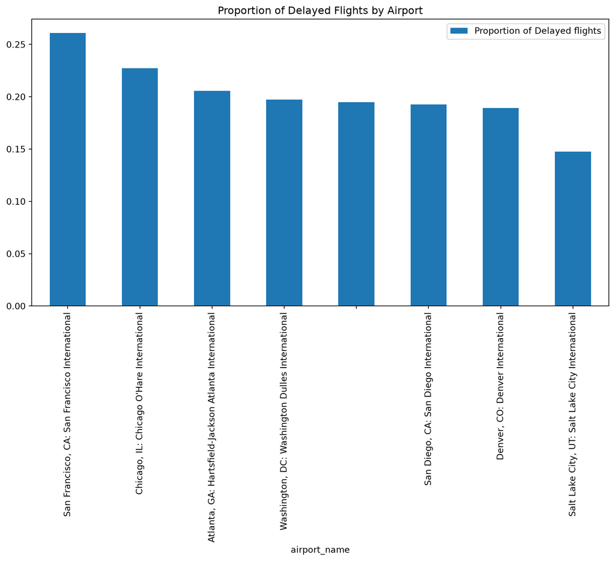

```python
df_plot = worse_airport.to_pandas()

# 2. Cria o gráfico direto de uma vez só!
df_plot.plot.bar(
    x='airport_name',
    y='Proportion of Delayed flights',
    title='Proportion of Delayed Flights by Airport',
    figsize=(12, 6)
)
```